# Interview Challenge -- BNY Mellon

## 1. Business Problem Statement.

## 2. Data Challenge Table

### Table 1: Customers

| Column Header | Description |
| --- | --- |
| customer_id | Unique identifier for each customer |
| age | Age of the customer |
| job | Type of job of the customer |
| marital_status | Marital status of the customer |
| education_level | Highest level of education attained by the customer |
| default_history | Whether the customer has a history of credit default (Yes, No) |
| housing_loan_status | Whether the customer has a housing loan (Yes, No) |
| personal_loan_status | Whether the customer has a personal loan (Yes, No) |
| credit_score | Credit score of the customer, range from 300-850 |

### Table 2: Transactions

| Column Header | Description |
| --- | --- |
| transaction_id | Unique identifier for each transaction |
| customer_id | Unique identifier for each customer |
| date | Date of the transaction |
| transaction_amount | The amount of the transaction |
| transaction_type | The type of the transaction (Deposit, Withdrawal) |
| balance_after_transaction | The balance of the customer's account after the transaction |

### Load Data

```python
import pandas as pd
customers = pd.read_csv('https://storage.googleapis.com/datalynn-datasets/interview-challenge/finance/BNY_Mellon_credit%20card/customers.csv')
transactions = pd.read_csv('https://storage.googleapis.com/datalynn-datasets/interview-challenge/finance/BNY_Mellon_credit%20card/transactions.csv')
```

## 3. Questions for the Data Challenge

### 3.1 Data Manipulation

- If you notice that certain customer records are missing in the transaction data, how would you modify your data consolidation process to accommodate this? What impact might this have on your analysis?
- Suppose you find that some customers have transactions recorded before their account creation date. How would you address this discrepancy?

**Ans** 3.1.1:

```python
consolidated_data = pd.merge(customers, transactions, on='customer_id', how='left')
```

**Ans** 3.1.2:

```python
# Ensure dates are in datetime format
transactions['date'] = pd.to_datetime(transactions['date'])

# Let's assume that the earliest possible 'account_creation_date' for all customers is the earliest date in the transactions dataset.
earliest_transaction_date = transactions['date'].min()
customers['account_creation_date'] = earliest_transaction_date

# Find minimum transaction date for each customer
min_transaction_date = transactions.groupby('customer_id')['date'].min().reset_index()
min_transaction_date.columns = ['customer_id', 'min_transaction_date']

# Merge this with the customers data
customers = pd.merge(customers, min_transaction_date, on='customer_id', how='left')

# If account creation date is later than the first transaction date, set it as the first transaction date
customers.loc[customers['account_creation_date'] > customers['min_transaction_date'], 'account_creation_date'] = customers['min_transaction_date']

# Drop the 'min_transaction_date' as it's not needed anymore
customers = customers.drop('min_transaction_date', axis=1)
```

### 3.2 Metric Selection

- Imagine you are presenting your model to stakeholders who are not data scientists. They are interested in the model's performance but find traditional classification metrics hard to interpret. How would you quantify the model's performance in a more intuitive way?
- Consider the imbalance of classes in the 'default_history' variable (assuming more customers have 'No' than 'Yes'). How might this impact the performance metric you chose, and how would you address this issue?

**Ans** 3.2.1:

**Ans** 3.2.2:

There is a library in Python called imbalanced-learn which is a popular choice to handle imbalanced datasets. Let's use it to oversample the minority class using the SMOTE (Synthetic Minority Over-sampling Technique) method.

```python
!pip install imbalanced-learn
```

```python
from sklearn.preprocessing import LabelEncoder
from sklearn.compose import make_column_transformer
from sklearn.preprocessing import OneHotEncoder
from imblearn.over_sampling import SMOTE
import numpy as np

# Create a copy to not modify the original data
customers_copy = customers.copy()

# Convert 'Yes' and 'No' in 'default_history' to numerical values
encoder = LabelEncoder()
customers_copy['default_history'] = encoder.fit_transform(customers_copy['default_history'])

# Convert datetime to Unix timestamp (number of seconds since 1970-01-01)
for col in customers_copy.select_dtypes(include=[np.datetime64]):
    customers_copy[col] = customers_copy[col].astype(np.int64) // 10**9

# Assuming that these are the categorical columns in your dataset
categorical_cols = ['job', 'marital_status', 'education_level', 'housing_loan_status', 'personal_loan_status']

# Transform categorical variables to dummy variables
transformer = make_column_transformer(
    (OneHotEncoder(), categorical_cols),
    remainder='passthrough'
)

X = transformer.fit_transform(customers_copy.drop('default_history', axis=1))
y = customers_copy['default_history']

# Use SMOTE to balance the classes
smote = SMOTE(sampling_strategy='minority')
X_sm, y_sm = smote.fit_resample(X, y)

# Check the balance of the classes after the oversampling
print(pd.Series(y_sm).value_counts())
```

```
1    509
0    509
Name: default_history, dtype: int64
```

### 3.3 Feature Engineering

- Our stakeholders believe that customers' banking behavior may exhibit certain patterns during different times of the year. How would you engineer the 'date' feature to capture this?
- Given the transaction data, propose three creative features that might predict a customer's default risk. Explain why you expect them to be useful.

**Ans** 3.3.1:

```python
# Ensure 'date' column is in datetime format
transactions['date'] = pd.to_datetime(transactions['date'])

# Create 'month', 'quarter', and 'day_of_week' features
transactions['month'] = transactions['date'].dt.month
transactions['quarter'] = transactions['date'].dt.quarter
transactions['day_of_week'] = transactions['date'].dt.dayofweek
```

**Ans** 3.3.2:

```python
import pandas as pd
from sklearn.model_selection import train_test_split
from sklearn.linear_model import LogisticRegression
from sklearn.preprocessing import StandardScaler, OneHotEncoder
from sklearn.compose import make_column_transformer
from sklearn.pipeline import make_pipeline
from sklearn.impute import SimpleImputer

# Ensure 'date' column in transactions is in datetime format
transactions['date'] = pd.to_datetime(transactions['date'])

# Create 'month_year' feature for aggregating transactions on a monthly basis
transactions['month_year'] = transactions['date'].dt.to_period('M')

# Compute Transaction Frequency and Average Transaction Amount
transaction_frequency = transactions.groupby(['customer_id', 'month_year'])['transaction_id'].count().reset_index().rename(columns={"transaction_id": "transaction_frequency"})
average_transaction_amount = transactions.groupby(['customer_id', 'month_year'])['transaction_amount'].mean().reset_index().rename(columns={"transaction_amount": "average_transaction_amount"})

# Compute Monthly Balance Trend as the difference between the maximum and minimum balance in the month
balance_max = transactions.groupby(['customer_id', 'month_year'])['balance_after_transaction'].max().reset_index().rename(columns={"balance_after_transaction": "balance_max"})
balance_min = transactions.groupby(['customer_id', 'month_year'])['balance_after_transaction'].min().reset_index().rename(columns={"balance_after_transaction": "balance_min"})
monthly_balance_trend = pd.merge(balance_max, balance_min, on=['customer_id', 'month_year'])
monthly_balance_trend['monthly_balance_trend'] = monthly_balance_trend['balance_max'] - monthly_balance_trend['balance_min']
```

### 3.4 Model Selection

Predict potential credit default risks for our customers considering dynamic transaction data?

**Ans** 3.4:

```python
# Merge all dynamic features
dynamic_features = pd.merge(pd.merge(transaction_frequency, average_transaction_amount, on=['customer_id', 'month_year']), monthly_balance_trend, on=['customer_id', 'month_year'])

# Merge dynamic features with customer data
df = pd.merge(customers, dynamic_features, on='customer_id', how='left')

# Assuming 'default_history' is the target variable
# Convert 'default_history' into binary format
df['default_history'] = df['default_history'].map({'No': 0, 'Yes': 1})

# Define preprocessor
preprocessor = make_column_transformer(
    (make_pipeline(SimpleImputer(strategy='mean'), StandardScaler()),
     ['age', 'credit_score', 'transaction_frequency', 'average_transaction_amount', 'monthly_balance_trend']),
    (OneHotEncoder(drop='first'), ['job', 'marital_status', 'education_level', 'housing_loan_status', 'personal_loan_status'])
)

# Define model
model = make_pipeline(
    preprocessor,
    LogisticRegression(solver='liblinear')
)

# Split data into training and test sets
X_train, X_test, y_train, y_test = train_test_split(
    df.drop(['customer_id', 'default_history', 'month_year', 'balance_max', 'balance_min'], axis=1),
    df['default_history'],
    test_size=0.2,
    random_state=0
)

# Train model
model.fit(X_train, y_train)

# Make predictions on test set
y_pred = model.predict(X_test)
```

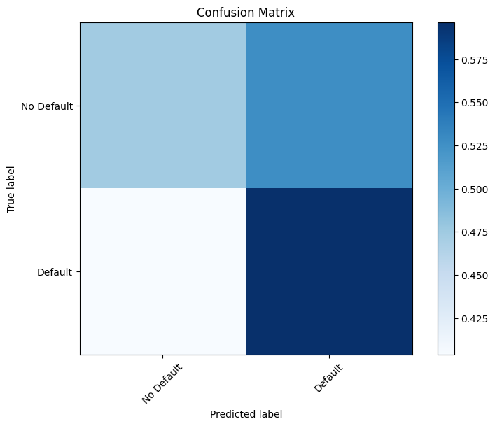

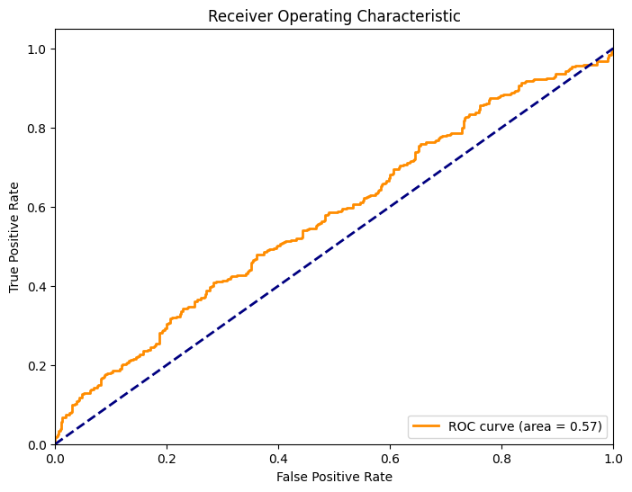

```python
import matplotlib.pyplot as plt
from sklearn.metrics import confusion_matrix, roc_curve, auc

# Compute confusion matrix
cm = confusion_matrix(y_test, y_pred)
cm_normalized = cm.astype('float') / cm.sum(axis=1)[:, np.newaxis]

# Plot confusion matrix
plt.figure(figsize=(8, 6))
plt.imshow(cm_normalized, interpolation='nearest', cmap=plt.cm.Blues)
plt.title('Confusion Matrix')
plt.colorbar()
tick_marks = np.arange(2)
plt.xticks(tick_marks, ['No Default', 'Default'], rotation=45)
plt.yticks(tick_marks, ['No Default', 'Default'])
plt.tight_layout()
plt.ylabel('True label')
plt.xlabel('Predicted label')
plt.show()

# Compute ROC curve and ROC area
fpr, tpr, _ = roc_curve(y_test, model.predict_proba(X_test)[:, 1])
roc_auc = auc(fpr, tpr)

# Plot ROC curve
plt.figure(figsize=(8, 6))
plt.plot(fpr, tpr, color='darkorange', lw=2, label='ROC curve (area = %0.2f)' % roc_auc)
plt.plot([0, 1], [0, 1], color='navy', lw=2, linestyle='--')
plt.xlim([0.0, 1.0])
plt.ylim([0.0, 1.05])
plt.xlabel('False Positive Rate')
plt.ylabel('True Positive Rate')
plt.title('Receiver Operating Characteristic')
plt.legend(loc="lower right")
plt.show()
```

### 3.5 Model Optimization

Let's say your model's performance has room for improvement. Can you think of a non-traditional approach you could take to enhance your model, leveraging the specific context of our data or problem?

**Ans** 3.5:

```python
from sklearn.ensemble import RandomForestClassifier, VotingClassifier

# Define preprocessor for the logistic regression
preprocessor1 = make_column_transformer(
    (make_pipeline(SimpleImputer(strategy='mean'), StandardScaler()),
     ['age', 'credit_score', 'transaction_frequency', 'average_transaction_amount', 'monthly_balance_trend']),
    (OneHotEncoder(drop='first'), ['job', 'marital_status', 'education_level', 'housing_loan_status', 'personal_loan_status'])
)

# Define preprocessor for the random forest
preprocessor2 = make_column_transformer(
    (make_pipeline(SimpleImputer(strategy='mean'), StandardScaler()),
     ['age', 'credit_score']),
    (OneHotEncoder(drop='first'), ['job', 'marital_status', 'education_level', 'housing_loan_status', 'personal_loan_status'])
)

# Define the logistic regression model
model1 = make_pipeline(
    preprocessor1,
    LogisticRegression(solver='liblinear')
)

# Define the random forest model
model2 = make_pipeline(
    preprocessor2,
    RandomForestClassifier(n_estimators=100, random_state=0)
)

# Define the voting classifier, with two estimators: logistic regression and random forest
voting_clf = VotingClassifier(
    estimators=[('lr', model1), ('rf', model2)],
    voting='soft'
)

# Train the voting classifier
voting_clf.fit(X_train, y_train)

# Make predictions on the test set
y_pred = voting_clf.predict(X_test)
```

### 3.6 Model Evaluation and Business Insights

- Assume your model is now in production and making predictions on new customers. How would you set up a system to evaluate whether the model's predictions are remaining accurate over time? Write a Python script demonstrating your approach.
- Discuss how you would set up a system to monitor and update your model over time. What potential issues would you anticipate, and how would you address them?